# New York Texi rate prediction: Machine Learning Nano degree project capstone

Data Exploration:

In this section, I will be exploring the data: Number of features, datatypes, meaning and gathering statistics. Run the code cell below to load necessary Python libraries and load the New York rate data

```python
# Import libraries necessary for this project
import numpy as np
import pandas as pd
from time import time
from IPython.display import display # Allows the use of display() for DataFrames

# Pretty display for notebooks
import matplotlib.pyplot as plt
import seaborn as sns
% matplotlib inline
plt.style.use('seaborn-whitegrid')
```

As the dataset is huge, for exploration phase I will reload subset of the data.

```python
# Load the Census train dataset
data = pd.read_csv("Data/train/train.csv", nrows = 1_000_000, parse_dates=["pickup_datetime"])

# Success - Display the first record
display(data.head(n=10))
```

|  | key | fare_amount | pickup_datetime | pickup_longitude | pickup_latitude | dropoff_longitude | dropoff_latitude | passenger_count |
| --- | --- | --- | --- | --- | --- | --- | --- | --- |
| 0 | 2009-06-15 17:26:21.0000001 | 4.5 | 2009-06-15 17:26:21 | -73.844311 | 40.721319 | -73.841610 | 40.712278 | 1 |
| 1 | 2010-01-05 16:52:16.0000002 | 16.9 | 2010-01-05 16:52:16 | -74.016048 | 40.711303 | -73.979268 | 40.782004 | 1 |
| 2 | 2011-08-18 00:35:00.00000049 | 5.7 | 2011-08-18 00:35:00 | -73.982738 | 40.761270 | -73.991242 | 40.750562 | 2 |
| 3 | 2012-04-21 04:30:42.0000001 | 7.7 | 2012-04-21 04:30:42 | -73.987130 | 40.733143 | -73.991567 | 40.758092 | 1 |
| 4 | 2010-03-09 07:51:00.000000135 | 5.3 | 2010-03-09 07:51:00 | -73.968095 | 40.768008 | -73.956655 | 40.783762 | 1 |
| 5 | 2011-01-06 09:50:45.0000002 | 12.1 | 2011-01-06 09:50:45 | -74.000964 | 40.731630 | -73.972892 | 40.758233 | 1 |
| 6 | 2012-11-20 20:35:00.0000001 | 7.5 | 2012-11-20 20:35:00 | -73.980002 | 40.751662 | -73.973802 | 40.764842 | 1 |
| 7 | 2012-01-04 17:22:00.00000081 | 16.5 | 2012-01-04 17:22:00 | -73.951300 | 40.774138 | -73.990095 | 40.751048 | 1 |
| 8 | 2012-12-03 13:10:00.000000125 | 9.0 | 2012-12-03 13:10:00 | -74.006462 | 40.726713 | -73.993078 | 40.731628 | 1 |
| 9 | 2009-09-02 01:11:00.00000083 | 8.9 | 2009-09-02 01:11:00 | -73.980658 | 40.733873 | -73.991540 | 40.758138 | 2 |

```python
# Load the Census test dataset
test = pd.read_csv("Data/test/test.csv", parse_dates=["pickup_datetime"])
display(test.head(n=10))
```

|  | key | pickup_datetime | pickup_longitude | pickup_latitude | dropoff_longitude | dropoff_latitude | passenger_count |
| --- | --- | --- | --- | --- | --- | --- | --- |
| 0 | 2015-01-27 13:08:24.0000002 | 2015-01-27 13:08:24 | -73.973320 | 40.763805 | -73.981430 | 40.743835 | 1 |
| 1 | 2015-01-27 13:08:24.0000003 | 2015-01-27 13:08:24 | -73.986862 | 40.719383 | -73.998886 | 40.739201 | 1 |
| 2 | 2011-10-08 11:53:44.0000002 | 2011-10-08 11:53:44 | -73.982524 | 40.751260 | -73.979654 | 40.746139 | 1 |
| 3 | 2012-12-01 21:12:12.0000002 | 2012-12-01 21:12:12 | -73.981160 | 40.767807 | -73.990448 | 40.751635 | 1 |
| 4 | 2012-12-01 21:12:12.0000003 | 2012-12-01 21:12:12 | -73.966046 | 40.789775 | -73.988565 | 40.744427 | 1 |
| 5 | 2012-12-01 21:12:12.0000005 | 2012-12-01 21:12:12 | -73.960983 | 40.765547 | -73.979177 | 40.740053 | 1 |
| 6 | 2011-10-06 12:10:20.0000001 | 2011-10-06 12:10:20 | -73.949013 | 40.773204 | -73.959622 | 40.770893 | 1 |
| 7 | 2011-10-06 12:10:20.0000003 | 2011-10-06 12:10:20 | -73.777282 | 40.646636 | -73.985083 | 40.759368 | 1 |
| 8 | 2011-10-06 12:10:20.0000002 | 2011-10-06 12:10:20 | -74.014099 | 40.709638 | -73.995106 | 40.741365 | 1 |
| 9 | 2014-02-18 15:22:20.0000002 | 2014-02-18 15:22:20 | -73.969582 | 40.765519 | -73.980686 | 40.770725 | 1 |

```python
# Features statistics
data.describe()
```

|  | fare_amount | pickup_longitude | pickup_latitude | dropoff_longitude | dropoff_latitude | passenger_count |
| --- | --- | --- | --- | --- | --- | --- |
| count | 1000000.000000 | 1000000.000000 | 1000000.000000 | 999990.000000 | 999990.000000 | 1000000.000000 |
| mean | 11.348079 | -72.526640 | 39.929008 | -72.527860 | 39.919954 | 1.684924 |
| std | 9.822090 | 12.057937 | 7.626154 | 11.324494 | 8.201418 | 1.323911 |
| min | -44.900000 | -3377.680935 | -3116.285383 | -3383.296608 | -3114.338567 | 0.000000 |
| 25% | 6.000000 | -73.992060 | 40.734965 | -73.991385 | 40.734046 | 1.000000 |
| 50% | 8.500000 | -73.981792 | 40.752695 | -73.980135 | 40.753166 | 1.000000 |
| 75% | 12.500000 | -73.967094 | 40.767154 | -73.963654 | 40.768129 | 2.000000 |
| max | 500.000000 | 2522.271325 | 2621.628430 | 45.581619 | 1651.553433 | 208.000000 |

From looking at the data distribution and statistics, reading article on new york Taxi rate and common sense :-), I can see that there are few anomalies in the data: latitude and longitude columns, passenger_count and fare_amount. I also have data points with missing values. Once I have identified outliers, I will remove them from the data set. I will start with removing data points with missing values

```python
# Remove na
print('Data set size before clean up process: %d' % len(data))
data = data.dropna()
print('Data set size after removeing null outliners: %d' % len(data))
```

```
Data set size before clean up process: 1000000
Data set size after removeing null outliners: 999990
```

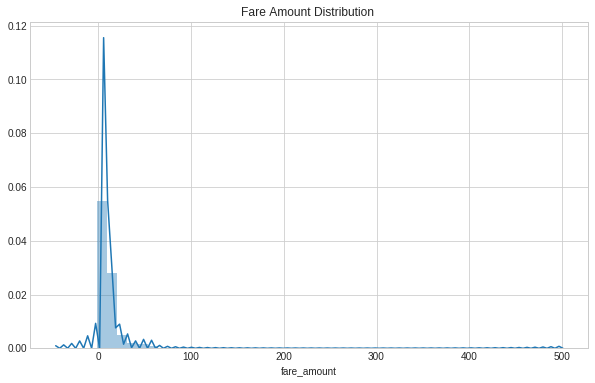

```python
# Fare amount visualization - Using seaborn's distplot, we will see both a kernel density estimate plot and a histogram.

plt.figure(figsize = (10, 6))
sns.distplot(data['fare_amount']);
plt.title('Fare Amount Distribution ');
```

Another plot for showing the distribution of a single variable is the empirical cumulative distribution (ECD) function. This shows the percentile on the y-axis and the variable on the x-axis. ECD is good for finding outliers and also the percentiles of a distribution.

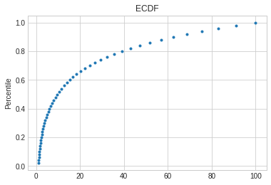

```python
def ecdf(x):

    # Sort in ascending order
    x = np.sort(x)
    n = len(x)
    y = np.arange(1, n + 1, 1) / n

    return x, y

xs, ys = ecdf(np.logspace(0, 2))
plt.plot(xs, ys, '.');
plt.ylabel('Percentile'); plt.title('ECDF');
```

From the graph we can see that most of the rides amount rate are smaller than 20. from 20 USD we can see that the graph is skewed right.

```python
# Remove fare amount outliers

data = data.loc[data['fare_amount']>2.5]
print('Data set size after removeing fare amount outliners: %d' % len(data))
```

```
Data set size after removeing fare amount outliners: 995910
```

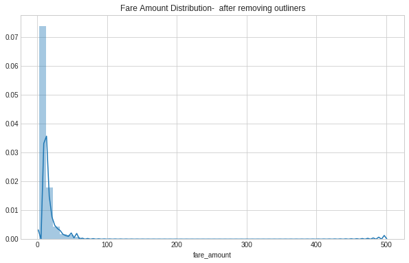

```python
# Fare amount visualization, afetr removeing outliners - Seaborn's distplot:

plt.figure(figsize = (10, 6))
sns.distplot(data['fare_amount']);
plt.title('Fare Amount Distribution-  after removing outliners');
```

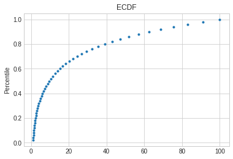

```python
# Fare amount visualization, afetr removeing outliners - ECDF plot:

xs1, ys1 = ecdf(np.logspace(0, 2))
plt.plot(xs1, ys1, '.');
plt.ylabel('Percentile'); plt.title('ECDF');
```

For the longitude/lattitude coordinates: We will look at the distribution and exclude longitude/lattitude coordinates that are off the norm. New York city coordinates are (https://www.latlong.net/place/new-york-city-ny-usa-1848.html): lattitude = 40.730610 longitude = -73.935242 To get a better view of the data, I will plot the train data set on New York Map (using domain knowlagde) And also use a diagram to present the data distribution

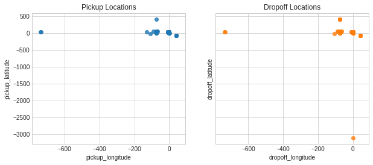

```python
# pickup and dropoff location visualization:
fig, axes = plt.subplots(1, 2, figsize = (10, 4), sharex=True, sharey=True)
axes = axes.flatten()

# Plot Longitude (x) and Latitude (y)
sns.regplot('pickup_longitude', 'pickup_latitude', fit_reg = False,
            data = data.sample(250000, random_state = 42), ax = axes[0]);
sns.regplot('dropoff_longitude', 'dropoff_latitude', fit_reg = False,
            data = data.sample(250000, random_state = 42), ax = axes[1]);
axes[0].set_title('Pickup Locations')
axes[1].set_title('Dropoff Locations');
```

We can see from the distribution diagram that there are outliners.

For a more contextualized representation, we can plot the pickup and dropoff New York city map. The map was extracted from OpenStreetMaps (https://www.openstreetmap.org/export#map=9/41.1528/-73.6496)

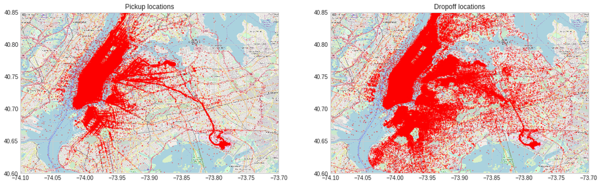

```python
# load New York map

BB = (-74.1, -73.7, 40.6, 40.85)

nyc_map = plt.imread('New_York_City_Map.PNG')


# this function will be used more often to plot data on the NYC map
def plot_on_map(data, BB, nyc_map, s=10, alpha=0.2):
    fig, axs = plt.subplots(1, 2, figsize=(18, 22))
    axs[0].scatter(data.pickup_longitude, data.pickup_latitude, zorder=1, alpha=alpha, c='r', s=s)
    axs[0].set_xlim((BB[0], BB[1]))
    axs[0].set_ylim((BB[2], BB[3]))
    axs[0].set_title('Pickup locations')
    axs[0].imshow(nyc_map, zorder=0, extent=BB)

    axs[1].scatter(data.dropoff_longitude, data.dropoff_latitude, zorder=1, alpha=alpha, c='r', s=s)
    axs[1].set_xlim((BB[0], BB[1]))
    axs[1].set_ylim((BB[2], BB[3]))
    axs[1].set_title('Dropoff locations')
    axs[1].imshow(nyc_map, zorder=0, extent=BB)

plot_on_map(data, BB, nyc_map, s=0.5, alpha=0.5)
```

Also from ploting the data on NYC map we can see that there are many outliers.

```python
# Remove latitude and longtiude outliers

data = data.loc[data['pickup_latitude'].between(40, 42)]
data = data.loc[data['pickup_longitude'].between(-75, -72)]
data = data.loc[data['dropoff_latitude'].between(40, 42)]
data = data.loc[data['dropoff_longitude'].between(-75, -72)]
print('Data set size after removing latitude and longitude outliers: %d' % len(data))
```

```
Data set size after removing latitude and longitude outliers: 975661
```

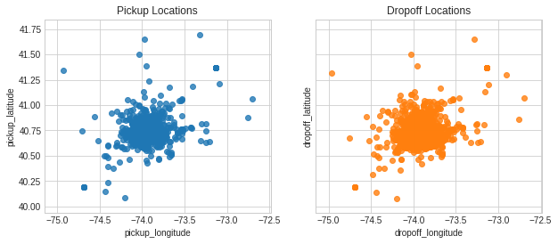

```python
# pickup and dropoff location visualization, afetr removeing outliners:
fig, axes = plt.subplots(1, 2, figsize = (10, 4), sharex=True, sharey=True)
axes = axes.flatten()

# Plot Longitude (x) and Latitude (y)
sns.regplot('pickup_longitude', 'pickup_latitude', fit_reg = False,
            data = data.sample(250000, random_state = 42), ax = axes[0]);
sns.regplot('dropoff_longitude', 'dropoff_latitude', fit_reg = False,
            data = data.sample(250000, random_state = 42), ax = axes[1]);
axes[0].set_title('Pickup Locations')
axes[1].set_title('Dropoff Locations');
```

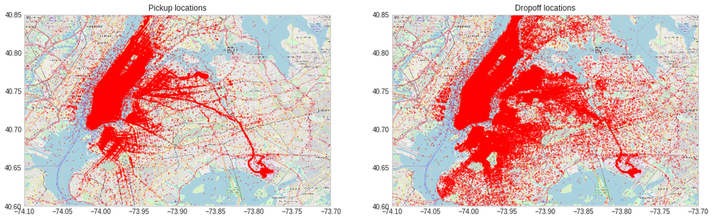

```python
# pickup and dropoff location visu1alization on NYC Map, afetr removeing outliners:

plot_on_map(data, BB, nyc_map, s=0.5, alpha=0.5)
```

Now the pickup and drop off distributions look much better.passenger_count: we will start with plotting a graph for passenger_count which seemed to have values that doesn't make sense.

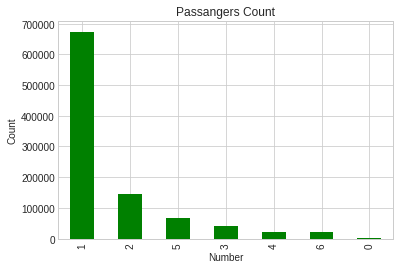

```python
data['passenger_count'].value_counts().plot.bar(color = 'g');
plt.title('Passangers Count'); plt.xlabel('Number'); plt.ylabel('Count');
```

Based on this graph, we will remove passenger counts greater than 6.

```python
# Remove passangers count outliers

data = data.loc[data['passenger_count']<=6]
print('Data set size after removing passanger count outliners: %d' % len(data))
```

```
Data set size after removing passanger count outliners: 975661
```

```python
# Features statistics, after clean up process
data.describe()
```

|  | fare_amount | pickup_longitude | pickup_latitude | dropoff_longitude | dropoff_latitude | passenger_count |
| --- | --- | --- | --- | --- | --- | --- |
| count | 975661.000000 | 975661.000000 | 975661.000000 | 975661.000000 | 975661.000000 | 975661.000000 |
| mean | 11.363810 | -73.975204 | 40.751090 | -73.974314 | 40.751430 | 1.685860 |
| std | 9.749911 | 0.038887 | 0.029902 | 0.038128 | 0.033084 | 1.308202 |
| min | 2.510000 | -74.968142 | 40.052722 | -74.964263 | 40.041180 | 0.000000 |
| 25% | 6.000000 | -73.992277 | 40.736592 | -73.991577 | 40.735607 | 1.000000 |
| 50% | 8.500000 | -73.982090 | 40.753427 | -73.980600 | 40.753886 | 1.000000 |
| 75% | 12.500000 | -73.968352 | 40.767597 | -73.965375 | 40.768427 | 2.000000 |
| max | 500.000000 | -72.702870 | 41.800252 | -72.196091 | 41.923820 | 6.000000 |

Feature Engineering: Two major features have impact on the taxi ride: 1. Distance - From many discussions in Kaggle's it seems like using the Haversine distance will be the best to calculate a more realistic distance between the pickup and dropoff. It is more accurate than Manhattan and Euclidean distances which are relative and do not take into account the spherical shape of the Earth. 2. Time (Different rate for day/nights and weekends/holidays)Calculating Haversine distance Feature:

```python
# Radius of the earth in kilometers
R = 6378

def haversine_distance(lon1, lat1, lon2, lat2):
    """
    Calculate the great circle distance between two points
    on the earth (specified in decimal degrees)

    All args must be of equal length.

    source: https://stackoverflow.com/a/29546836

    """
    # Convert latitude and longitude to radians
    lon1, lat1, lon2, lat2 = map(np.radians, [lon1, lat1, lon2, lat2])

    # Find the differences
    dlon = lon2 - lon1
    dlat = lat2 - lat1

    # Apply the formula
    a = np.sin(dlat/2.0)**2 + np.cos(lat1) * np.cos(lat2) * np.sin(dlon/2.0)**2
    # Calculate the angle (in radians)
    c = 2 * np.arcsin(np.sqrt(a))
    # Convert to kilometers
    km = R * c

    return km

data['haversine'] =  haversine_distance(data['pickup_longitude'], data['pickup_latitude'],
                         data['dropoff_longitude'], data['dropoff_latitude'])

test['haversine'] = haversine_distance(test['pickup_longitude'], test['pickup_latitude'],
                         test['dropoff_longitude'], test['dropoff_latitude'])
```

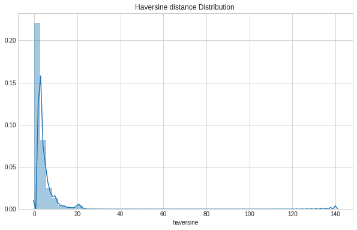

```python
plt.figure(figsize = (10, 6))
sns.distplot(data['haversine']);
plt.title('Haversine distance Distribution ');
```

Calculating Time Features:

```python
# add time features to the data
data['year'] = data.pickup_datetime.apply(lambda t: t.year)
data['weekday'] = data.pickup_datetime.apply(lambda t: t.weekday())
data['hour'] = data.pickup_datetime.apply(lambda t: t.hour )
```

```python
display(data.head(n=5))
```

|  | key | fare_amount | pickup_datetime | pickup_longitude | pickup_latitude | dropoff_longitude | dropoff_latitude | passenger_count | haversine | year | weekday | hour |
| --- | --- | --- | --- | --- | --- | --- | --- | --- | --- | --- | --- | --- |
| 0 | 2009-06-15 17:26:21.0000001 | 4.5 | 2009-06-15 17:26:21 | -73.844311 | 40.721319 | -73.841610 | 40.712278 | 1 | 1.031896 | 2009 | 0 | 17 |
| 1 | 2010-01-05 16:52:16.0000002 | 16.9 | 2010-01-05 16:52:16 | -74.016048 | 40.711303 | -73.979268 | 40.782004 | 1 | 8.459418 | 2010 | 1 | 16 |
| 2 | 2011-08-18 00:35:00.00000049 | 5.7 | 2011-08-18 00:35:00 | -73.982738 | 40.761270 | -73.991242 | 40.750562 | 2 | 1.391052 | 2011 | 3 | 0 |
| 3 | 2012-04-21 04:30:42.0000001 | 7.7 | 2012-04-21 04:30:42 | -73.987130 | 40.733143 | -73.991567 | 40.758092 | 1 | 2.802346 | 2012 | 5 | 4 |
| 4 | 2010-03-09 07:51:00.000000135 | 5.3 | 2010-03-09 07:51:00 | -73.968095 | 40.768008 | -73.956655 | 40.783762 | 1 | 2.001353 | 2010 | 1 | 7 |

```python
#Add features to test dataset
test['year'] = test.pickup_datetime.apply(lambda t: t.year)
test['weekday'] = test.pickup_datetime.apply(lambda t: t.weekday())
test['hour'] = test.pickup_datetime.apply(lambda t: t.hour )
```

Visulaizing time features to get a better undestanding of the data:

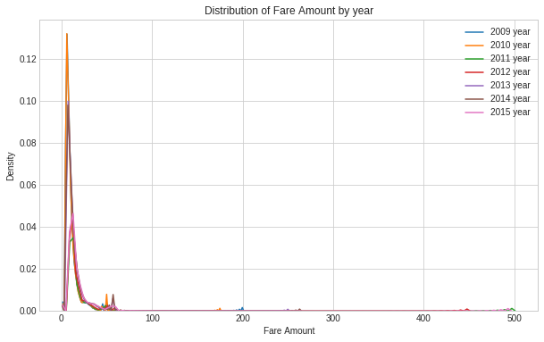

```python
#Year Feature
plt.figure(figsize = (10, 6))

for p, grouped in data.groupby('year'):
    sns.kdeplot(grouped['fare_amount'], label = f'{p} year')

plt.xlabel('Fare Amount'); plt.ylabel('Density')
plt.title('Distribution of Fare Amount by year');
```

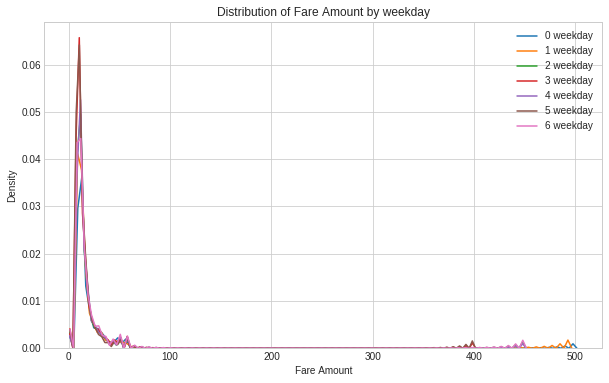

```python
#Weekday Feature
#5,6 are weekend days
plt.figure(figsize = (10, 6))

for p, grouped in data.groupby('weekday'):
    sns.kdeplot(grouped['fare_amount'], label = f'{p} weekday')

plt.xlabel('Fare Amount'); plt.ylabel('Density')
plt.title('Distribution of Fare Amount by weekday');
```

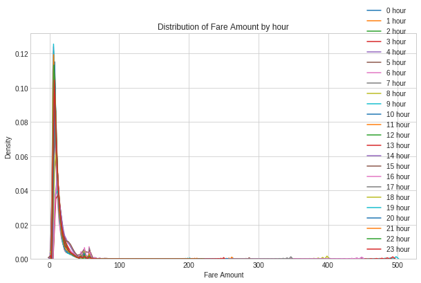

```python
#Hour Feature
plt.figure(figsize = (10, 6))

for p, grouped in data.groupby('hour'):
    sns.kdeplot(grouped['fare_amount'], label = f'{p} hour')

plt.xlabel('Fare Amount'); plt.ylabel('Density')
plt.title('Distribution of Fare Amount by hour');
```

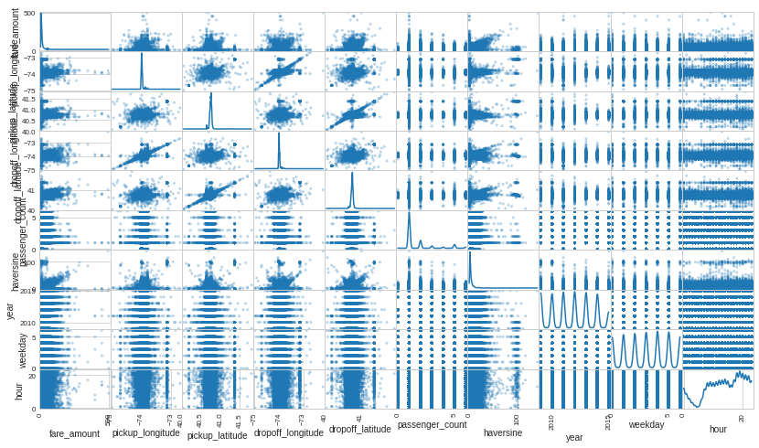

```python
subset = data.sample(100000, random_state=42)
# Produce a scatter matrix for each pair of features in the data
pd.scatter_matrix(data, alpha = 0.3, figsize = (14,8), diagonal = 'kde');
```

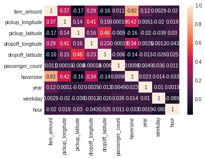

```python
import seaborn as sns
# calculate the correlation matrix
corr = subset.corr()

# plot the heatmap
sns.heatmap(corr, annot=True,
        xticklabels=corr.columns,
        yticklabels=corr.columns)
```

From the heatmap and scatter matrix we can find, as expected, a very strong linear correlation between the distance and the fare amount. I also noticed a small correlation between the year and the rate amount. I didn't see strong correlation to the hour/weekend.Model As mentioned in my proposal, we have here a classical supervised regression problem.

```python
#fare_amount = data['fare_amount']
fare_amount = np.asarray(data['fare_amount'], dtype="|S1")
features_final= data.drop(['key','fare_amount','pickup_datetime'], axis = 1)
test_final =test.drop(['key','pickup_datetime'], axis = 1)
```

```python
display(features_final.head(n=10))
```

|  | pickup_longitude | pickup_latitude | dropoff_longitude | dropoff_latitude | passenger_count | haversine | year | weekday | hour |
| --- | --- | --- | --- | --- | --- | --- | --- | --- | --- |
| 0 | -73.844311 | 40.721319 | -73.841610 | 40.712278 | 1 | 1.031896 | 2009 | 0 | 17 |
| 1 | -74.016048 | 40.711303 | -73.979268 | 40.782004 | 1 | 8.459418 | 2010 | 1 | 16 |
| 2 | -73.982738 | 40.761270 | -73.991242 | 40.750562 | 2 | 1.391052 | 2011 | 3 | 0 |
| 3 | -73.987130 | 40.733143 | -73.991567 | 40.758092 | 1 | 2.802346 | 2012 | 5 | 4 |
| 4 | -73.968095 | 40.768008 | -73.956655 | 40.783762 | 1 | 2.001353 | 2010 | 1 | 7 |
| 5 | -74.000964 | 40.731630 | -73.972892 | 40.758233 | 1 | 3.791400 | 2011 | 3 | 9 |
| 6 | -73.980002 | 40.751662 | -73.973802 | 40.764842 | 1 | 1.557516 | 2012 | 1 | 20 |
| 7 | -73.951300 | 40.774138 | -73.990095 | 40.751048 | 1 | 4.160010 | 2012 | 2 | 17 |
| 8 | -74.006462 | 40.726713 | -73.993078 | 40.731628 | 1 | 1.254608 | 2012 | 0 | 13 |
| 9 | -73.980658 | 40.733873 | -73.991540 | 40.758138 | 2 | 2.852758 | 2009 | 2 | 1 |

```python
# Import 'train_test_split'
from sklearn.cross_validation import train_test_split

# Shuffle and split the data into training and testing subsets

X_train, X_valid, y_train, y_valid =  train_test_split(features_final, fare_amount, test_size = 0.2, random_state=42)

print("Training and testing split was successful")
```

```
Training and testing split was successful
```

Evaluation Metrics: I will use the same evaluation metric required for the competition. The evaluation metric is the root mean-squared error or RMSE. RMSE measures the difference between the predictions of a model, and the corresponding ground truth. A large RMSE is equivalent to a large average error, so smaller values of RMSE are better. The error is given in the units being measured, so we will be able to tell very directly how incorrect the model might be on unseen data.

```python
from sklearn.metrics import mean_squared_error
from math import sqrt

def rmse(y_actual, y_predicted):
    rms = sqrt(mean_squared_error(y_actual.astype(float), y_predicted.astype(float)))
    return rms

def mse(y_actual, y_predicted):
    rms = mean_squared_error(y_actual.astype(float), y_predicted.astype(float))
    return rms
```

```python
def train_predict(learner, sample_size, X_train, y_train, X_valid, y_valid):
    '''
    inputs:
       - learner: the learning algorithm to be trained and predicted on
       - sample_size: the size of samples (number) to be drawn from training set
       - X_train: features training set
       - y_train: fare_amount training set
       - X_test: features testing set
       - y_test: fare_amount testing set
    '''
    print("Start running supervised regression models")

    print("Running {} model".format(learner.__class__.__name__))

    results = {}

    # Fit the learner to the training data using slicing with 'sample_size' using .fit(training_features[:], training_labels[:])
    start = time() # Get start time
    learner = learner.fit(X_train[:sample_size], y_train[:sample_size])
    end = time() # Get end time

    # Calculate the training time
    results['train_time'] = end-start


    # Get the predictions on the test set(X_test),
    # then get predictions on the first 300 training samples(X_train) using .predict()
    start = time() # Get start time
    y_predict_valid = learner.predict(X_valid)
    y_predict_train = learner.predict(X_train[:300])
    end = time() # Get end time

    # Calculate the total prediction time
    results['pred_time'] = end-start

    results['RMSE_train'] = rmse (y_predict_train,y_train[:300])
    results['RMSE_valid'] = rmse (y_predict_valid,y_valid)
    results['MSE_train'] = mse (y_predict_train,y_train[:300])
    results['MSE_valid'] = mse (y_predict_valid,y_valid)
    # Success
    print("{} trained on {} samples".format(learner.__class__.__name__, sample_size))
    print("{} RMSE for trained data is: {}".format(learner.__class__.__name__, results['RMSE_train']))
    print("{} RMSE for validated data is: {}".format(learner.__class__.__name__, results['RMSE_valid']))
    print("{} MSE for trained data is: {}".format(learner.__class__.__name__, results['MSE_train']))
    print("{} MSE for validated data is: {}".format(learner.__class__.__name__, results['MSE_valid']))

    # Return the results*/
    return results
```

```python
# Import thesupervised learning models from sklearn
from sklearn.naive_bayes import GaussianNB
from sklearn.svm import SVR
from sklearn.ensemble import RandomForestRegressor


#Initialize the three models
clf_A = GaussianNB()
clf_B = SVR()
clf_C = RandomForestRegressor(random_state=42)

#DEBUG: train_predict(clf_B, len(y_train), X_train, y_train, X_valid, y_valid)
# Collect results on the learners
results = {}
for clf in [clf_A, clf_C]:
    clf_name = clf.__class__.__name__
    results[clf_name] = {}
    results[clf_name] = train_predict(clf, len(y_train), X_train, y_train, X_valid, y_valid)
```

```
Start running supervised regression models
Running GaussianNB model
GaussianNB trained on 780528 samples
GaussianNB RMSE for trained data is: 3.533647784749729
GaussianNB RMSE for validated data is: 3.237861482958636
GaussianNB MSE for trained data is: 12.486666666666666
GaussianNB MSE for validated data is: 10.483746982827098
Start running supervised regression models
Running RandomForestRegressor model
RandomForestRegressor trained on 780528 samples
RandomForestRegressor RMSE for trained data is: 0.9299103899480494
RandomForestRegressor RMSE for validated data is: 2.053588579899758
RandomForestRegressor MSE for trained data is: 0.8647333333333332
RandomForestRegressor MSE for validated data is: 4.217226055494705
```

```python
from sklearn.model_selection import GridSearchCV
from sklearn.metrics import make_scorer
from sklearn.cross_validation import StratifiedShuffleSplit
# Initialize the classifier
clf = RandomForestRegressor(random_state=42)

parameters = {
    'n_estimators': [20],
    'max_features': ['sqrt', 'log2'],
    'max_depth' : [3,10,20],
    }



# Make an RMSE scoring object using make_scorer()
scorer = make_scorer(rmse)

# Perform grid search on the classifier using 'scorer' as the scoring method using GridSearchCV()
grid_obj = GridSearchCV(estimator=clf, param_grid=parameters, cv=5 ,scoring=scorer)

# Fit the grid search object to the training data and find the optimal parameters using fit()
grid_fit = grid_obj.fit(X_train, y_train)

# Get the estimator
best_clf = grid_fit.best_estimator_

# Make predictions using the unoptimized and model
predictions = (clf.fit(X_train, y_train)).predict(X_valid)
best_predictions = best_clf.predict(X_valid)

# Report the before-and-afterscores
print("Unoptimized model\n------")
print("RMSE score on testing data: {:.4f}".format(rmse(y_valid, predictions )))
print("MSE score on testing data: {:.4f}".format(mse(y_valid, predictions )))
print("\nOptimized Model\n------")
print("Final RMSE score on the testing data: {:.4f}".format(rmse(y_valid,best_predictions)))
print("Final MSE score on the testing data: {:.4f}".format(mse(y_valid,best_predictions)))
```

```
Unoptimized model
------
RMSE score on testing data: 2.0536
MSE score on testing data: 4.2172

Optimized Model
------
Final RMSE score on the testing data: 2.3295
Final MSE score on the testing data: 5.4266
```

```python
# Produce the value for 'max_depth'
print ("Parameter 'max_depth' is {} for the optimal model".format(best_clf.get_params()['max_depth']))
print ("Parameters used by optimal model are: {} ".format(best_clf.get_params()))
```

[output not shown]

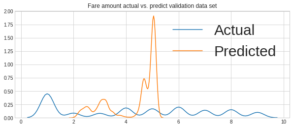

```python
#Visualization of actual vs. prediction validation dataset
plt.figure(figsize = (10, 4))
sns.kdeplot(y_valid, label = 'Actual')
sns.kdeplot(best_predictions, label = 'Predicted')
plt.legend(prop = {'size': 30})
plt.title("Fare amount actual vs. predict validation data set");
```

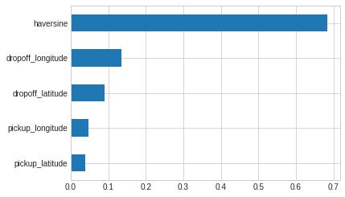

```python
# Train the supervised model on the training set using .fit(X_train, y_train)
model = best_clf

# Extract the feature importances using .feature_importances_
importances = model.feature_importances_

# Plot
pd.Series(importances, index=X_train.columns).sort_values()[-5:].plot(kind='barh');
```

# Deep learning model

```python
from sklearn.preprocessing import MinMaxScaler
scaler = MinMaxScaler()
X_train_scaled = scaler.fit_transform(X_train).astype(float)
X_valid_scaled = scaler.transform(X_valid).astype(float)
```

```python
from keras.layers import Conv2D, MaxPooling2D, GlobalAveragePooling2D
from keras.layers import Dropout, Flatten, Dense
from keras.models import Sequential
from keras.layers import BatchNormalization



model = Sequential()

BatchNormalization(epsilon=1e-06, mode=0, momentum=0.9, weights=None)
model.add(Dense(128, activation='relu', input_shape=(X_train_scaled.shape[1],)))

model.add(Dropout(0.25))

model.add(Dense(64, activation='relu'))
model.add(Dropout(0.25))

model.add(Dense(32, activation='relu'))
model.add(Dropout(0.25))

model.add(Dense(16, activation='relu'))
model.add(Dropout(0.25))

model.add(Dense(8, activation='relu'))
model.add(Dropout(0.5))
model.add(Dense(1, activation='relu'))

model.summary()
```

```
_________________________________________________________________
Layer (type)                 Output Shape              Param #
=================================================================
dense_1 (Dense)              (None, 128)               1280
_________________________________________________________________
dropout_1 (Dropout)          (None, 128)               0
_________________________________________________________________
dense_2 (Dense)              (None, 64)                8256
_________________________________________________________________
dropout_2 (Dropout)          (None, 64)                0
_________________________________________________________________
dense_3 (Dense)              (None, 32)                2080
_________________________________________________________________
dropout_3 (Dropout)          (None, 32)                0
_________________________________________________________________
dense_4 (Dense)              (None, 16)                528
_________________________________________________________________
dropout_4 (Dropout)          (None, 16)                0
_________________________________________________________________
dense_5 (Dense)              (None, 8)                 136
_________________________________________________________________
dropout_5 (Dropout)          (None, 8)                 0
_________________________________________________________________
dense_6 (Dense)              (None, 1)                 9
=================================================================
Total params: 12,289
Trainable params: 12,289
Non-trainable params: 0
_________________________________________________________________
```

```python
#compile the model
model.compile(loss='mse', optimizer='adam', metrics=['mae'])
```

```python
from keras.callbacks import ModelCheckpoint

# Specify the number of epochs that you would like to use to train the model.

epochs = 10


checkpointer = ModelCheckpoint(filepath='saved_models/weights.best.from_scratch.hdf5',
                               verbose=1, save_best_only=True)

model.fit(X_train_scaled, y_train,
          validation_data=(X_valid_scaled, y_valid),
          epochs=epochs, batch_size=5, callbacks=[checkpointer], verbose=1)
```

```
Train on 780528 samples, validate on 195133 samples
```

```
<keras.callbacks.History at 0x7f90f6954828>
```

Load the Model with the Best Validation Loss

```python
model.load_weights('saved_models/weights.best.from_scratch.hdf5')
```

test the model

```python
y_predict_train_DL = model.predict(X_train_scaled[:300], batch_size=128, verbose=1)
y_predict_valid_DL = model.predict(X_valid_scaled, batch_size=128, verbose=1)
```

```python
# report test metrics

RMSE_train = rmse (y_predict_train_DL,y_train[:300])
RMSE_valid = rmse (y_predict_valid_DL,y_valid)
MSE_train = mse (y_predict_train_DL,y_train[:300])
MSE_valid = mse (y_predict_valid_DL,y_valid)

print("RMSE for trained data is: {}".format(RMSE_train))
print("RMSE for validated data is: {}".format(RMSE_valid))
print("MSE for trained data is: {}".format(MSE_train))
print("MSE for validated data is: {}".format(MSE_valid))
```

```
RMSE for trained data is: 2.2135036500315177
RMSE for validated data is: 2.240302812030765
MSE for trained data is: 4.899598408702852
MSE for validated data is: 5.018956689592953
```